# Forecasting US Energy Consumption

March 24, 2022

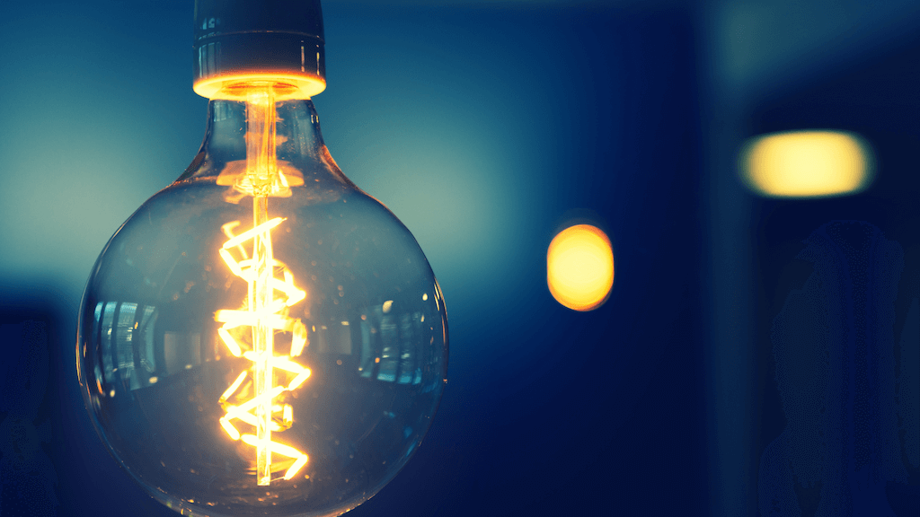

Forecasting US Energy Consumption

## Goal:

The goal of this project is to build a model to forecast the US energy consumption.

## About Data

The data is downloaded from the eia’s website which is a U.S Energy Information Administration and does independent Statistics and Analysis.

https://www.eia.gov/totalenergy/data/browser/xls.php?tbl=T02.01&freq=m

## Importing Modules

```r
install.packages("rlang", repos = "http://cran.us.r-project.org")
install.packages("fpp3", repos = "http://cran.us.r-project.org")
install.packages("readxl", repos = "http://cran.us.r-project.org")
install.packages("tsibble", repos = "http://cran.us.r-project.org")
install.packages("tseries", repos = "http://cran.us.r-project.org")
library(tseries)
library(fpp3)
library(tsibble)
library(readxl)
library(dplyr)
library(knitr)
```

```r
#Clearing variables
rm(list=ls())
```

## EDA

```r
#Reading Data
data <-read_excel("D:/D_ST/VCU/Spring 2022/DAPT-632 Forecasting/Case/Total Energy Consumption.xlsx")
```

```r
#Converting to a tsibble
data$Month = yearmonth(data$Month)
data <- as_tsibble(data, index = Month )
```

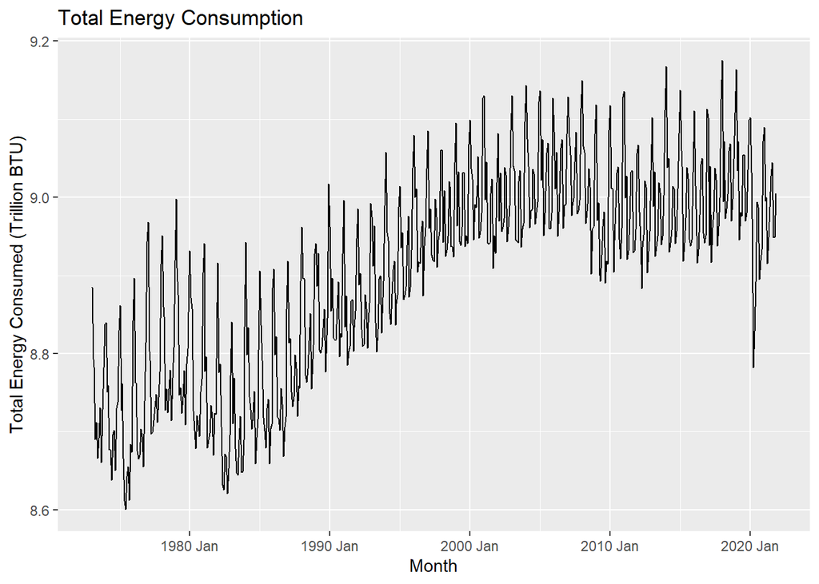

```r
#Visualize Data
data %>%
  autoplot(log(TotalEnergyConsumption)) +
  xlab("Month") +
  ylab("Total Energy Consumed (Trillion BTU)") +
  ggtitle("Total Energy Consumption")
```

It can be seen from the above graph that Energy consumption has a increasing Trend and have monthly seasonality. From year 2000 to 2021 the trend seems to damped which is because energy industry is changing very fast as more renewable energy coming into picture and there have been several national energy-efficiency policy coming into place.

Since, Energy Consumption changed drastically over time period, let’s consider data for last two decades

```r
data<- data %>%
      filter(year(Month) > 2000) %>%
      select(Month,TotalEnergyConsumption )
```

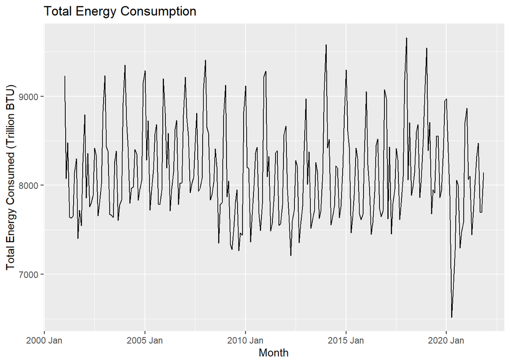

```r
#Visualize Data
data %>%
  autoplot(TotalEnergyConsumption) +
  xlab("Month") +
  ylab("Total Energy Consumed (Trillion BTU)") +
  ggtitle("Total Energy Consumption")
```

At a glance we can see that there is definitively seasonality in the Energy Consumption and it dropped drastically in month of April 2020 because of the lock down that the world saw when the Covid-19 hit. But energy consumption gradually reached the same pace as the business reopened.

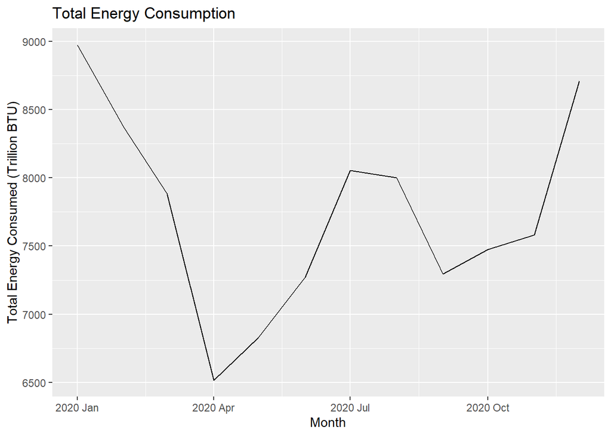

```r
#Visualize Data for 2020
data %>%
  filter(year(Month) == 2020)  %>%
  select(Month,TotalEnergyConsumption )  %>%
  autoplot(TotalEnergyConsumption) +
  xlab("Month") +
  ylab("Total Energy Consumed (Trillion BTU)") +
  ggtitle("Total Energy Consumption")
```

For year 2020, there is sudden dip in Energy Consumption for month of April and it started catching up in July.

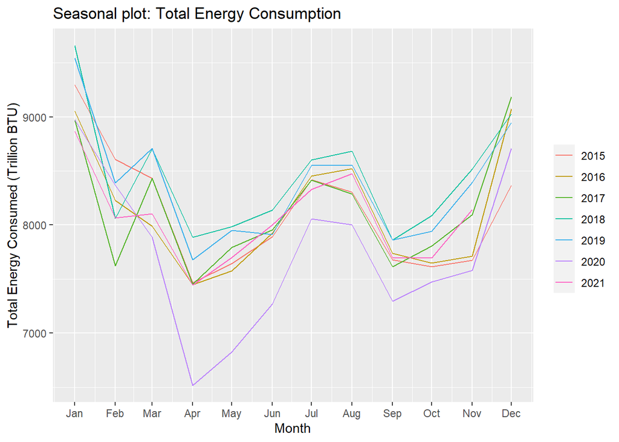

```r
#Plotting Seasonality
data %>%
  filter(year(Month) > 2014) %>%
  gg_season(TotalEnergyConsumption, period = "year") +
  labs(y = "Total Energy Consumed (Trillion BTU)" ,
       title = "Seasonal plot: Total Energy Consumption")
```

```r
data %>%
  gg_subseries(TotalEnergyConsumption) +
  labs(
    y = "Total Energy Consumed (Trillion BTU)",
    title =  "Seasonal SubSeries: Total Energy Consumption")
```

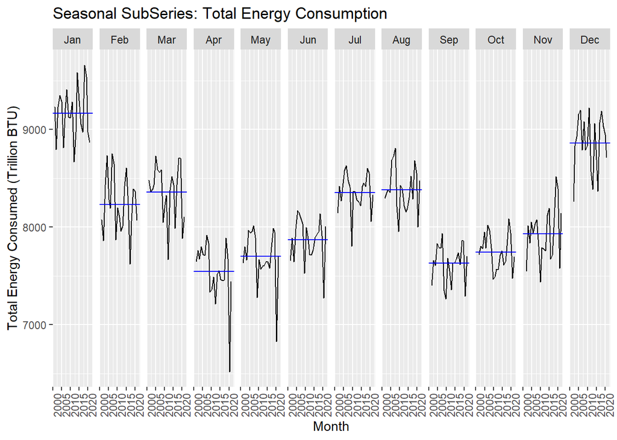

It is clear from the above gg_subseries plot that the lowest energy consumption was seen in month April, May, June of year 2020.

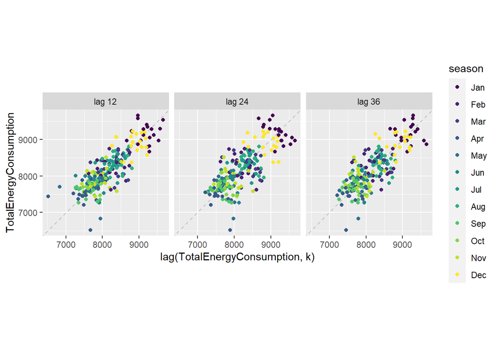

```r
#Plotting Lags
data %>%
  gg_lag(TotalEnergyConsumption, geom = "point", lags = c(12,24,36)) +
  labs(x = "lag(TotalEnergyConsumption, k)")
```

```r
data %>%
  gg_lag(TotalEnergyConsumption, geom = "point") +
  labs(x = "lag(TotalEnergyConsumption, k)")
```

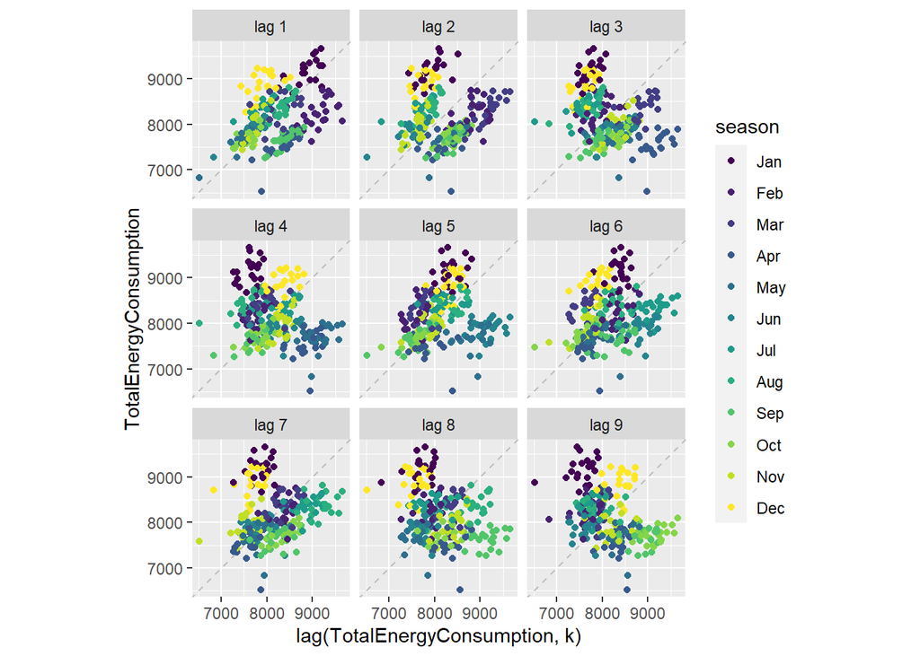

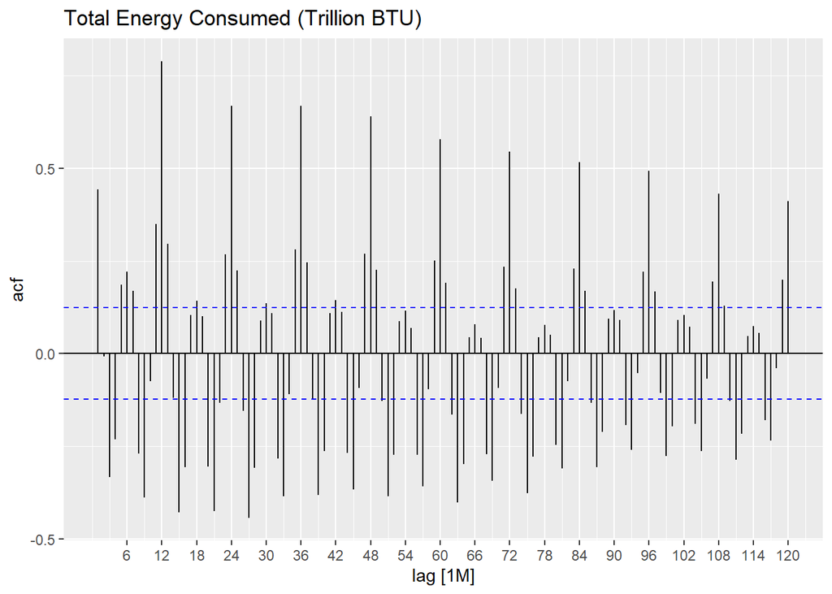

```r
# Plotting the auto Correlations
data %>%
  ACF(TotalEnergyConsumption, lag_max = 120) %>%
  autoplot() + labs(title="Total Energy Consumed (Trillion BTU)")
```

- The ACF plot there is ‘Trend’ in our data since the ACF is slowly decreasing as our lags are increasing.
- The peaks can be observed at lag 12, 24, 36 showing seasonal lags.
- The alternating(Sinusoidal) and tapering pattern suggests that there is higher order auto-regressive term in the data and a AR model will be well suited for forecasting this Time Series Data.

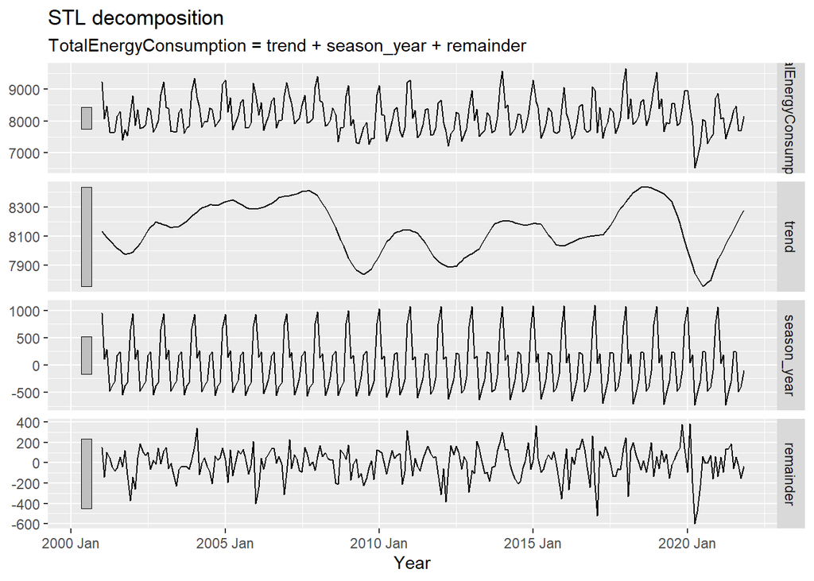

```r
#STL Without season window
dcmp <- data %>%
        model(STL(TotalEnergyConsumption))

#STL WITH SEASON WINDOW
Sdcmp <- data %>%
  model(STL(TotalEnergyConsumption ~ season(window= "periodic"), robust = TRUE))

#Plotting all components
components(dcmp) %>% autoplot() + xlab("Year")
```

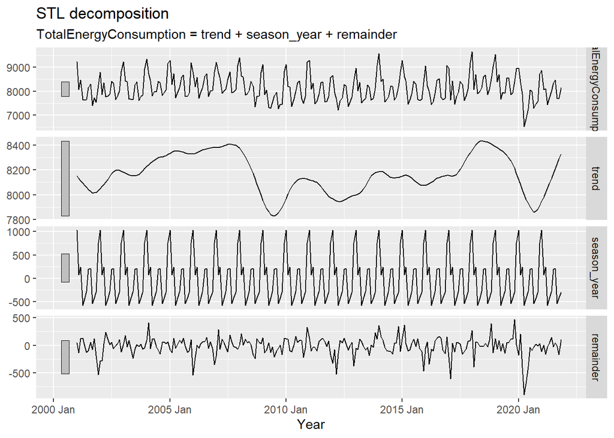

```r
components(Sdcmp) %>% autoplot() + xlab("Year")
```

The Trend line exhibits a little changing behavior so we will try ETS with additive trend and Without trend. The Seasonality changes in magnitude each year so a additive method seems necessary. The Error changes in magnitude as the series goes along so a multiplicative method will be used. This leaves us with an ETS(M,N,A) and ET(M,A,A) model.

## ARIMA

```r
# Number of non seasonal differences required(d)
data %>%
  mutate(log_TEC = (TotalEnergyConsumption)) %>%
  features(log_TEC, unitroot_nsdiffs)
```

```
## # A tibble: 1 x 1
##   nsdiffs
##     <int>
## 1       1
```

```r
# Number of Seasonal differences required(D)
data %>%
  mutate(log_TEC = difference((TotalEnergyConsumption), 12)) %>%
  features(log_TEC, unitroot_ndiffs)
```

```
## # A tibble: 1 x 1
##   ndiffs
##    <int>
## 1      0
```

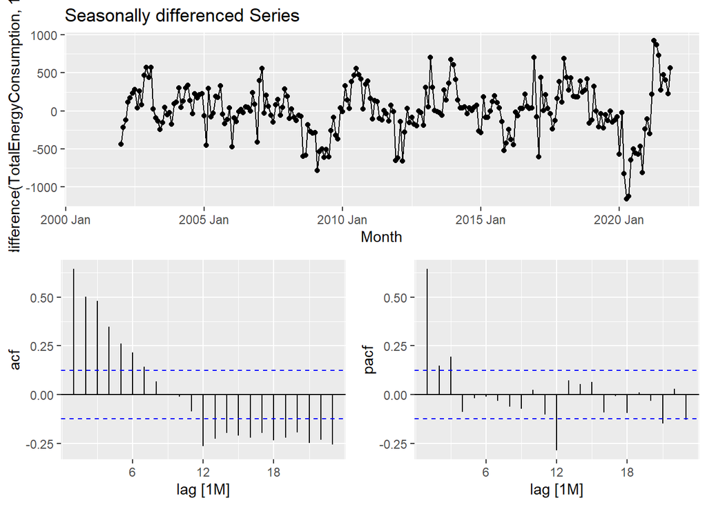

```r
# ACF and PACF plot for Seasonally differenced data  Total Energy Consumption
data %>%
  gg_tsdisplay((difference(TotalEnergyConsumption, 12)), plot_type='partial') +
  labs(title="Seasonally differenced Series")
```

The p-value of the KPSS test will be 0.01 or 0.1. It is 0.01 if the actual p-value is less than 0.01 and 0.1 if it is greater than 0.1

If p value = 0.01 : Reject the Null : Data is Not Stationary If p value = 0.1 : Fail to Reject Null : Data is Stationary

```r
# KPPS
data %>%
  features((TotalEnergyConsumption), unitroot_kpss)
```

```
## # A tibble: 1 x 2
##   kpss_stat kpss_pvalue
##       <dbl>       <dbl>
## 1     0.156         0.1
```

The p-value is 0.1. Therefore, we fail to reject the null hypothesis, the data is stationary. Now let’s run a bunch of models

## Modeling

```r
# Dividing data set into Test and Train

#Train Set
data_train <- data %>%
              filter(year(Month) != 2021)

#Test Set
data_test <- data %>%
             filter(year(Month) == 2021)
```

## Fitting Multiple Models

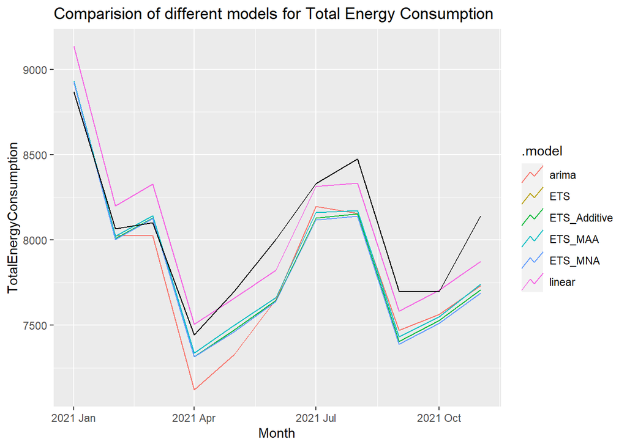

```r
# Fit Model
fit_mul <- data_train %>%
  model(
    #TSLM
    linear = TSLM((TotalEnergyConsumption) ~ trend() + season()),
    #ETS
    ETS = ETS((TotalEnergyConsumption)),
    ETS_Additive = ETS(TotalEnergyConsumption ~ error("A")+trend("A")+season("A")),
    ETS_MAA = ETS((TotalEnergyConsumption) ~ error("M") + trend("A") + season("A")),
    ETS_MNA = ETS((TotalEnergyConsumption) ~ error("M") + trend("N") + season("A")),
    #ARIMA
    arima = ARIMA(TotalEnergyConsumption, stepwise = FALSE, approx = FALSE)
    )

# Forecast
fc_mul <- fit_mul %>%
  forecast(h = 11)

#Plot the Forecast
fc_mul %>%
  autoplot(level = NULL) +
  autolayer(data_test, TotalEnergyConsumption) +
  labs(title = "Comparision of different models for Total Energy Consumption")
```

## Checking Accuracy of Models

```r
# Checking Accuracy of Models
accuracy <-  accuracy(fc_mul, data)
View(accuracy)
```

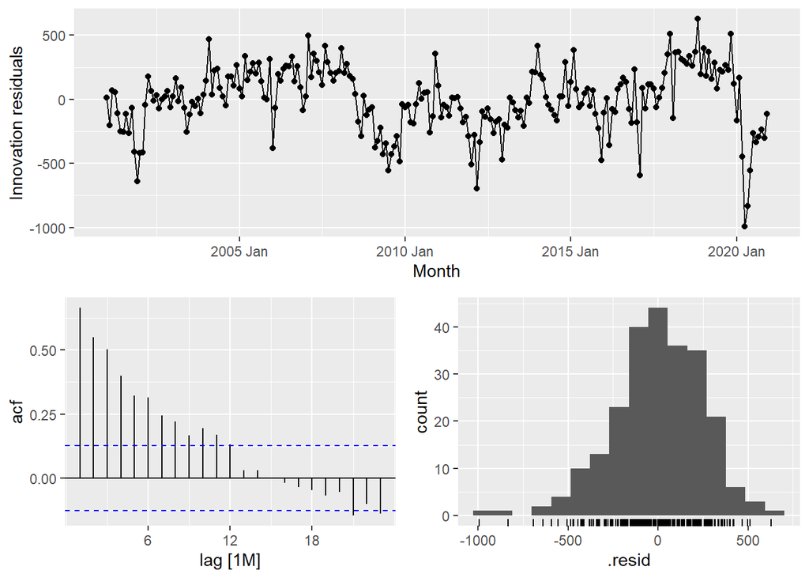

```r
best_model_1 <- fit_mul %>% select(linear)
best_model_1 %>% gg_tsresiduals()
```

```r
report(best_model_1)
```

```
## Series: TotalEnergyConsumption
## Model: TSLM
## Transformation: (TotalEnergyConsumption)
##
## Residuals:
##     Min      1Q  Median      3Q     Max
## -993.12 -138.11   15.01  177.70  627.58
##
## Coefficients:
##                  Estimate Std. Error t value Pr(>|t|)
## (Intercept)     9216.9869    63.9033 144.233  < 2e-16 ***
## trend()           -0.3338     0.2404  -1.389 0.166216
## season()year2   -937.8768    81.4810 -11.510  < 2e-16 ***
## season()year3   -808.3006    81.4821  -9.920  < 2e-16 ***
## season()year4  -1628.6137    81.4838 -19.987  < 2e-16 ***
## season()year5  -1476.5100    81.4863 -18.120  < 2e-16 ***
## season()year6  -1311.8491    81.4895 -16.098  < 2e-16 ***
## season()year7   -821.1903    81.4934 -10.077  < 2e-16 ***
## season()year8   -801.4480    81.4980  -9.834  < 2e-16 ***
## season()year9  -1550.0864    81.5033 -19.019  < 2e-16 ***
## season()year10 -1429.1075    81.5093 -17.533  < 2e-16 ***
## season()year11 -1257.7512    81.5161 -15.429  < 2e-16 ***
## season()year12  -314.6528    81.5235  -3.860 0.000148 ***
## ---
## Signif. codes:  0 '***' 0.001 '**' 0.01 '*' 0.05 '.' 0.1 ' ' 1
##
## Residual standard error: 257.7 on 227 degrees of freedom
## Multiple R-squared: 0.7911,  Adjusted R-squared: 0.7801
## F-statistic: 71.64 on 12 and 227 DF, p-value: < 2.22e-16
```

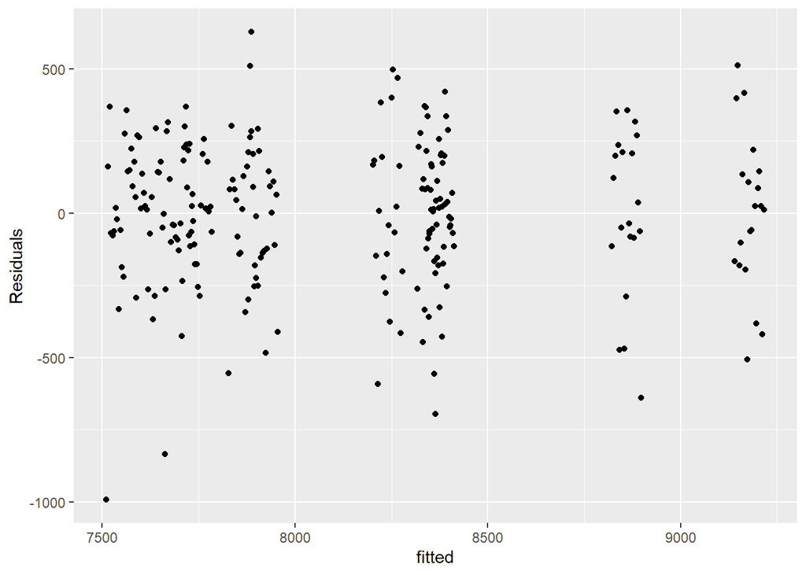

```r
# Residual Plot against fitted values
augment(best_model_1) %>%
  ggplot(aes(x = .fitted, y = .resid)) +
  geom_point() + labs(x = "fitted", y = "Residuals")
```

The residuals looks randomly scattered, there seems to be gaps in residuals.

```r
# ljung_box Test
augment(best_model_1) %>%
    features(.resid, ljung_box, lag = 24, dof = 12)
```

```
## # A tibble: 1 x 3
##   .model lb_stat lb_pvalue
##   <chr>    <dbl>     <dbl>
## 1 linear    420.         0
```

The p-value of this model comes out to be zero, it implies the model errors are auto-correlated.

### 2nd Best Model

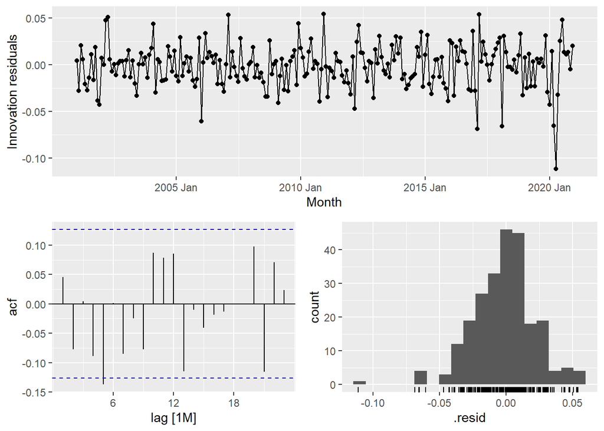

```r
best_model_2 <- fit_mul %>% select(ETS_MAA)
best_model_2 %>% gg_tsresiduals()
```

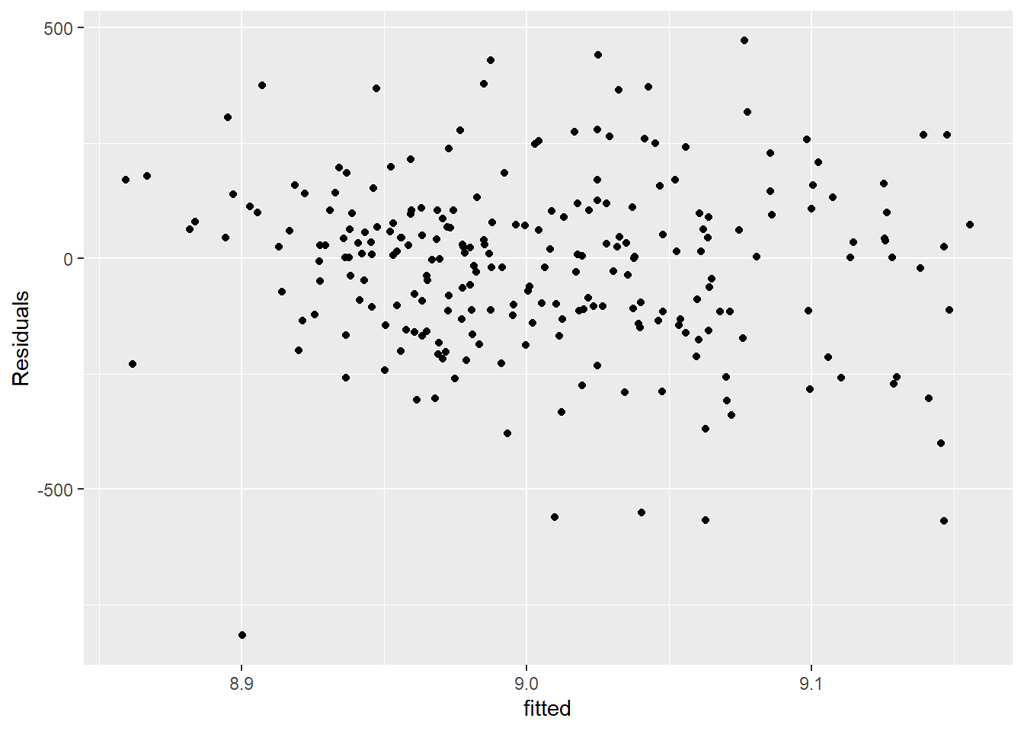

```r
# Residual Plot against fitted values
augment(best_model_2) %>%
  ggplot(aes(x = log(.fitted), y = .resid)) +
  geom_point() + labs(x = "fitted", y = "Residuals")
```

```r
# ljung_box Test
augment(best_model_2) %>%
    features(.resid, ljung_box, lag = 24, dof = 16)
```

```
## # A tibble: 1 x 3
##   .model  lb_stat   lb_pvalue
##   <chr>     <dbl>       <dbl>
## 1 ETS_MAA    44.5 0.000000467
```

## Cross Validation

```r
data_sets <- data %>%
  stretch_tsibble(.init = 50, .step = 10)

fit_mul_CV <- data_sets %>%
  model(
         #TSLM
        linear = TSLM((TotalEnergyConsumption) ~ trend() + season()),
        #ETS
        ETS = ETS((TotalEnergyConsumption)),
        ETS_Additive = ETS(TotalEnergyConsumption ~ error("A")+trend("A")+season("A")),
        ETS_MAA = ETS((TotalEnergyConsumption) ~ error("M") + trend("A") + season("A")),
        ETS_MNA = ETS((TotalEnergyConsumption) ~ error("M") + trend("N") + season("A")),
        #ARIMA
        arima = ARIMA(TotalEnergyConsumption, stepwise = FALSE, approx = FALSE)
       )

fc_mul_CV <- fit_mul_CV %>%
  forecast(h = 11)

accuracy_CV <-  accuracy(fc_mul_CV, data)
View(accuracy_CV)
```

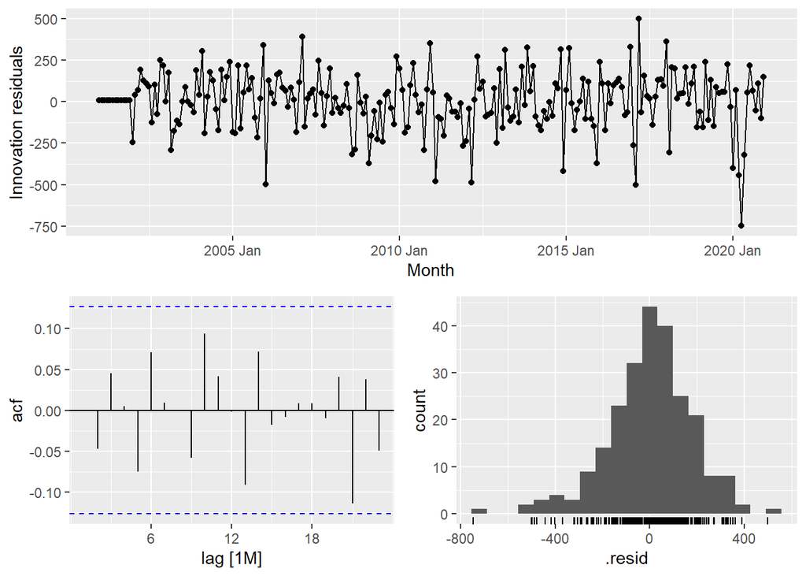

```r
best_model_cv <- fit_mul %>% select(arima)
best_model_cv %>% gg_tsresiduals()
```

ACF plot shows all the lags are within the bound there are no significant correlation in residuals and the time series represent white noise. The histogram also looks perfect except one outlier.

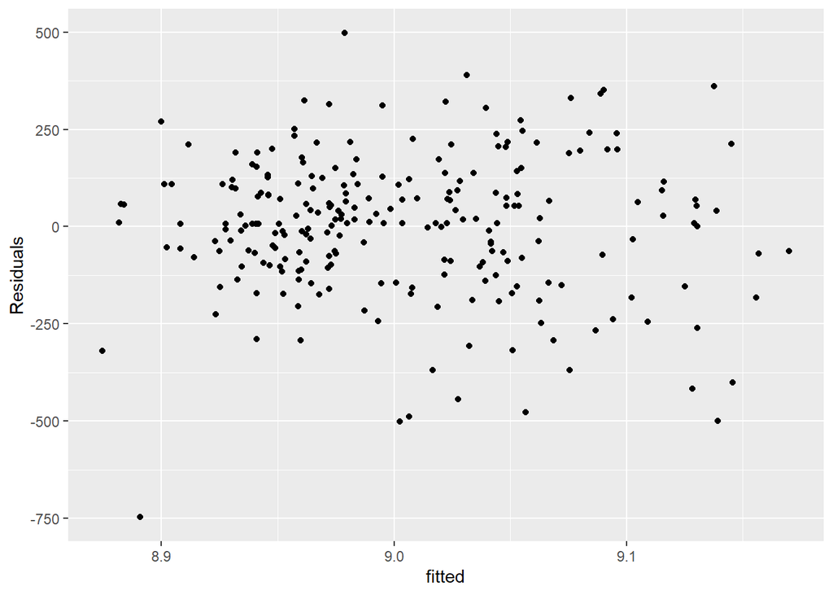

```r
#Residual Plot against fitted values
augment(best_model_cv) %>%
  ggplot(aes(x = log(.fitted), y = .resid)) +
  geom_point() + labs(x = "fitted", y = "Residuals")
```

Residuals looks randomly scattered, this means there is no Heteroscedasticity.

```r
#ljung_box Test
augment(best_model_cv) %>%
    features(.resid, ljung_box, lag = 24, dof = 14)
```

```
## # A tibble: 1 x 3
##   .model lb_stat lb_pvalue
##   <chr>    <dbl>     <dbl>
## 1 arima     15.7     0.107
```

```r
#ljung_box Test
report(best_model_cv)
```

```
## Series: TotalEnergyConsumption
## Model: ARIMA(1,0,1)(2,1,2)[12]
##
## Coefficients:
##          ar1      ma1    sar1     sar2     sma1    sma2
##       0.9000  -0.4427  0.4839  -0.4198  -1.2401  0.4128
## s.e.  0.0423   0.0835  0.1607   0.0778   0.1700  0.1605
##
## sigma^2 estimated as 34425:  log likelihood=-1521.76
## AIC=3057.52   AICc=3058.03   BIC=3081.52
```

## Vizualizing Forecast

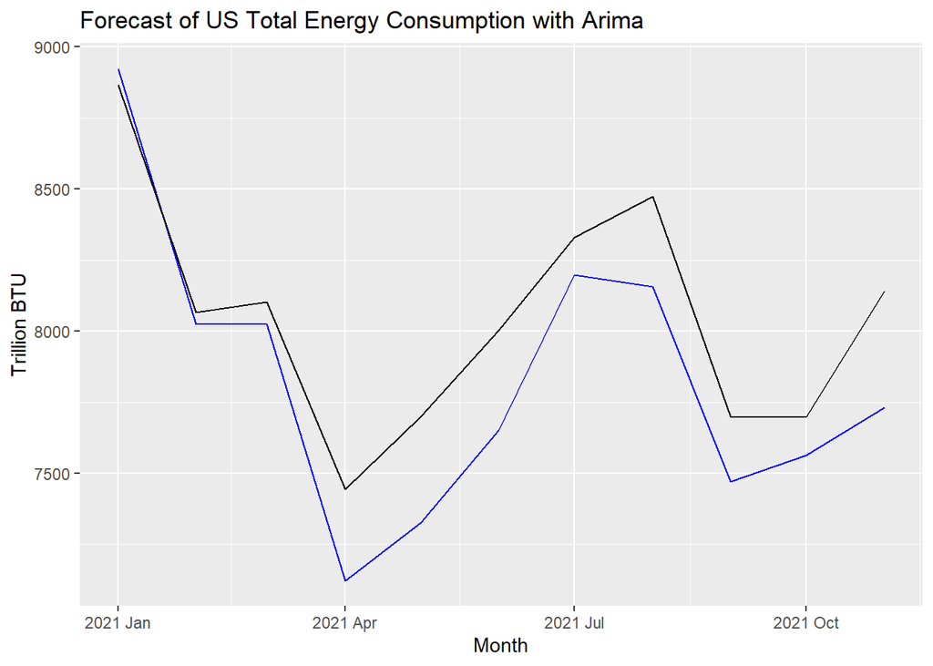

```r
data_train %>%
  model(ARIMA(TotalEnergyConsumption, stepwise = FALSE, approx = FALSE)) %>%
  forecast(h=11) %>%
  autoplot(data_test, level = NULL) +
  labs(title = "Forecast of US Total Energy Consumption with Arima",
       y = "Trillion BTU")
```

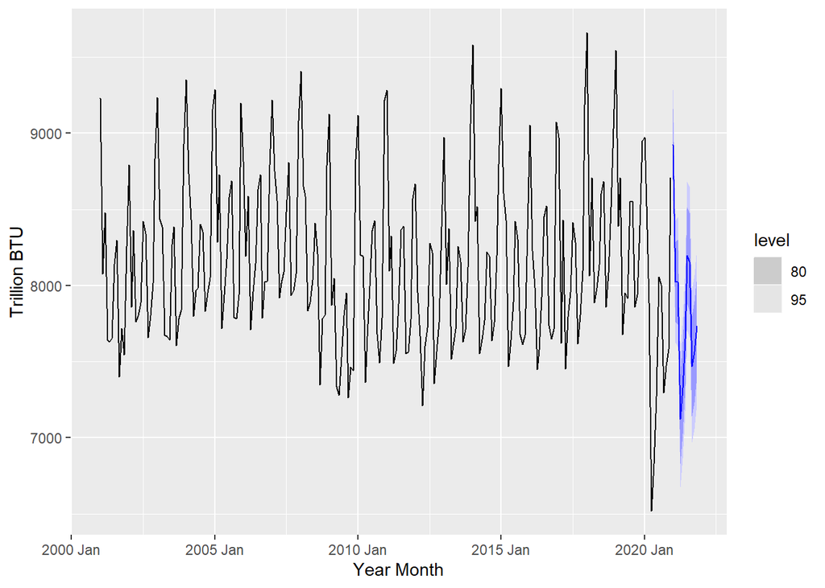

```r
data_train %>%
  model(ARIMA(TotalEnergyConsumption, stepwise = FALSE, approx = FALSE)) %>%
  forecast(h=11) %>%
  autoplot(data_train) +
  labs(x = "Year Month",
       y = "Trillion BTU")
```

## Modelling out the Covid Impact by adding Indicator Variables (ARIMA VS LINEAR)

```r
#Adding Indicator Variable
df<- data %>%
      mutate(Covid_indicator = if_else( month(Month) == 4 & year(Month) == 2020, 1, 0))
```

```r
# Dividing data set into Test and Train

#Train Set
df_train <- df %>%
  filter(year(Month) != 2021)

#Test Set
df_test <- df %>%
  filter(year(Month) == 2021)
```

```r
# Model Fitting
fit_linear = df_train %>% model(TSLM((TotalEnergyConsumption) ~ trend() + season() + Covid_indicator))

fit_arima = df_train %>% model(ARIMA(TotalEnergyConsumption, stepwise = FALSE, approx = FALSE))
```

```r
# Forecasting
fc_linear = fit_linear %>%
            forecast(
              new_data(df_train, 11) %>%
                       mutate(Covid_indicator = 0)
              )


fc_arima = fit_arima %>%
  forecast(h = 11)
```

```r
# Checking Accuracy
x <- bind_rows(
  fit_arima %>% accuracy(),
  fit_linear %>% accuracy(),
  fit_arima %>% forecast(h = 11) %>% accuracy(df),
  fit_linear %>% forecast(new_data(df_train, 11) %>% mutate(Covid_indicator = 0)) %>% accuracy(df)
) %>% select(.model, .type, RMSE,MAE,MAPE,)
View(x)
```

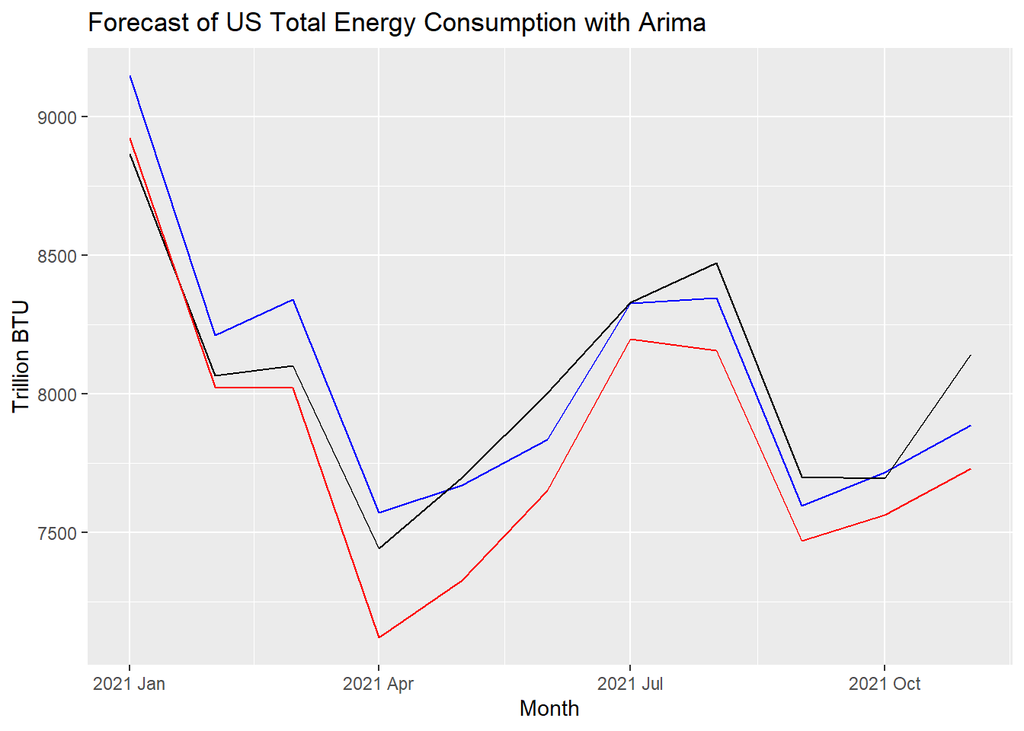

```r
#Vizualizing ARIMA and Linear Forecast
fc_linear %>%
  autoplot(df_test, level = NULL, colour = 'blue') +
  autolayer(fc_arima, level = NULL,colour = 'red')  +
  labs(title = "Forecast of US Total Energy Consumption with Arima",
       y = "Trillion BTU")  +
  guides(colour = guide_legend(title = "Forecast"))
```

CONCLUSION:

The Linear did better on Test dataset because it learned from all the past data and averaged out the effect of outlier (APRIL 2020). While on the other hand Arima learned most from it recent past (April 2020). Arima is going to take into account that the this will persist.

So, both models can be used, depending on the circumstance and we learned that how a poorly placed outlier can sway our forecasts.